# Power Harvesting Kit

14.03.2021

## 1mF capacitor.

## 40cm for 1mF capacitor.

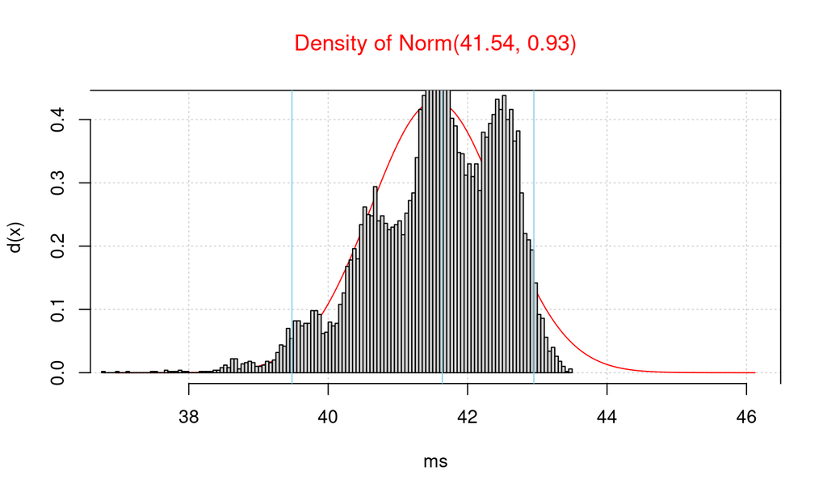

95% Confidence Interval: (39.48ms, 42.95ms)

## 60cm for 1mF capacitor.

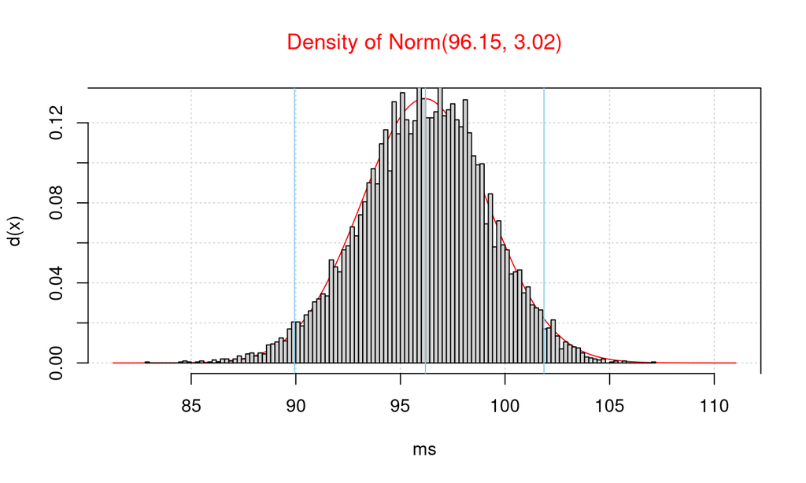

95% Confidence Interval: (89.94ms, 101.86ms)

## 80cm for 1mF capacitor.

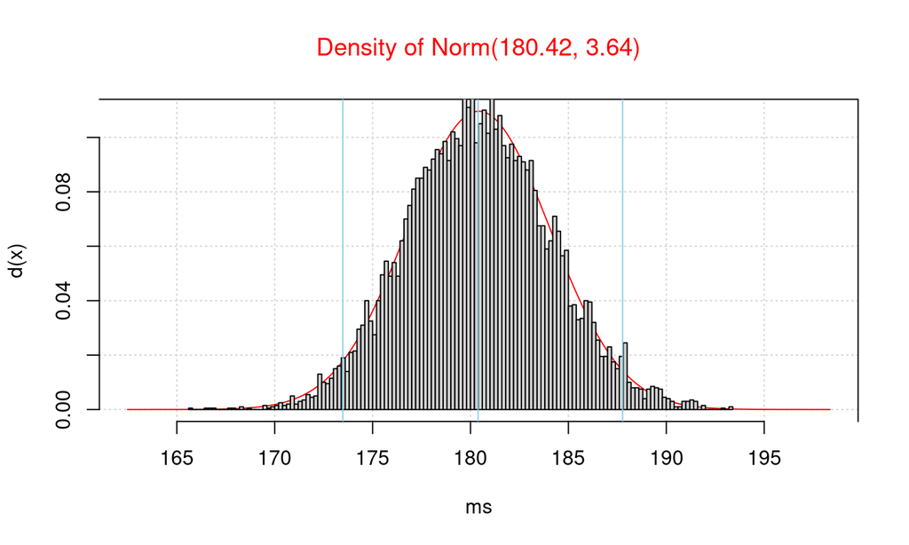

95% Confidence Interval: (173.48ms, 187.77ms)

## 100cm for 1mF capacitor.

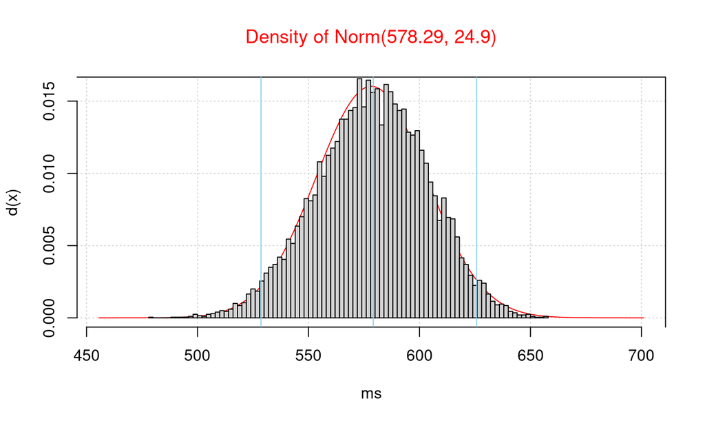

95% Confidence Interval: (528.6ms, 625.74ms)

## Summary

distances

means

errors

lower

higher

**\(\beta_0\)**

```
   40
```

41.54

0.93

39.48

42.95

**\(\beta_1\)**

```
   60
```

96.15

3.02

89.94

101.86

**\(\beta_2\)**

```
   80
```

180.42

3.64

173.48

187.77

**\(\beta_3\)**

```
  100
```

578.29

24.9

528.6

625.74

## 2mF capacitor.

## 40cm for 2mF capacitor.

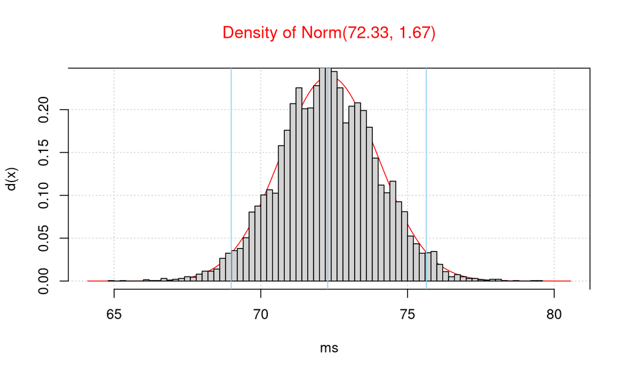

95% Confidence Interval: (68.99ms, 75.64ms)

## 60cm for 2mF capacitor.

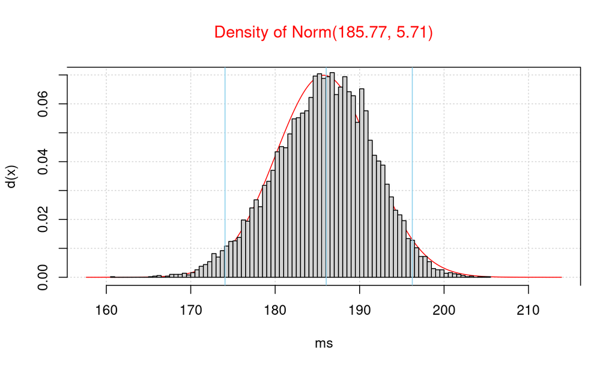

95% Confidence Interval: (174.06ms, 196.24ms)

## 80cm for 2mF capacitor.

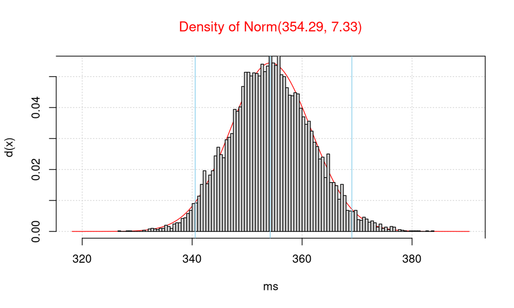

95% Confidence Interval: (340.55ms, 369.05ms)

## 100cm for 2mF capacitor.

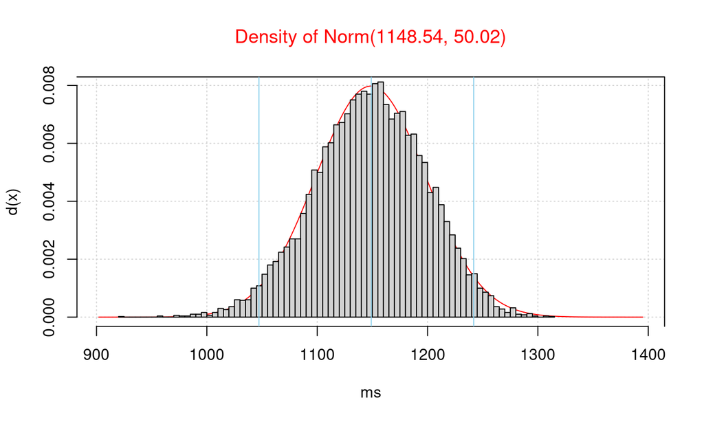

95% Confidence Interval: (1047.18ms, 1241.83ms)

## Summary

distances

means

errors

lower

higher

**\(\beta_0\)**

```
   40
```

72.33

1.67

68.99

75.64

**\(\beta_1\)**

```
   60
```

185.77

5.71

174.06

196.24

**\(\beta_2\)**

```
   80
```

354.29

7.33

340.55

369.05

**\(\beta_3\)**

```
  100
```

1148.54

50.02

1047.18

1241.83

## 5mF capacitor.

## 40cm for 5mF capacitor.

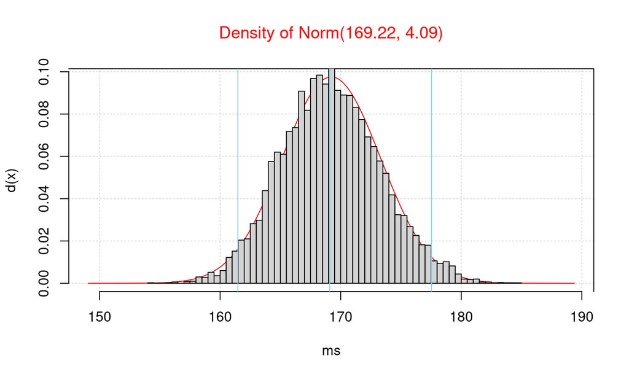

95% Confidence Interval: (161.47ms, 177.53ms)

## 60cm for 5mF capacitor.

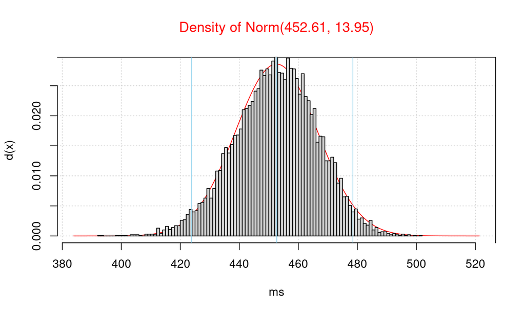

95% Confidence Interval: (423.87ms, 478.51ms)

## 80cm for 5mF capacitor.

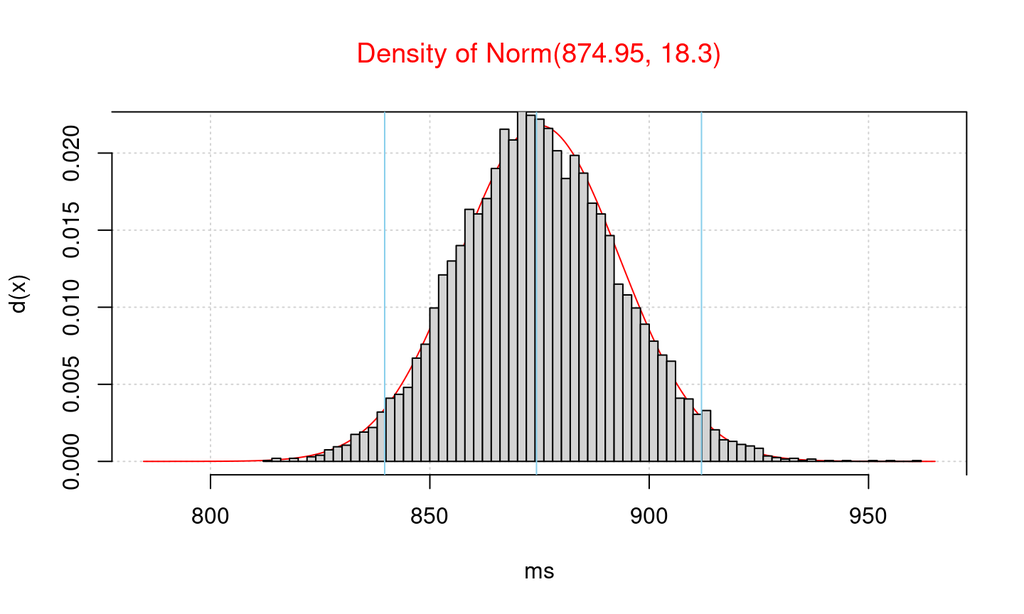

95% Confidence Interval: (839.7ms, 911.92ms)

## 100cm for 5mF capacitor.

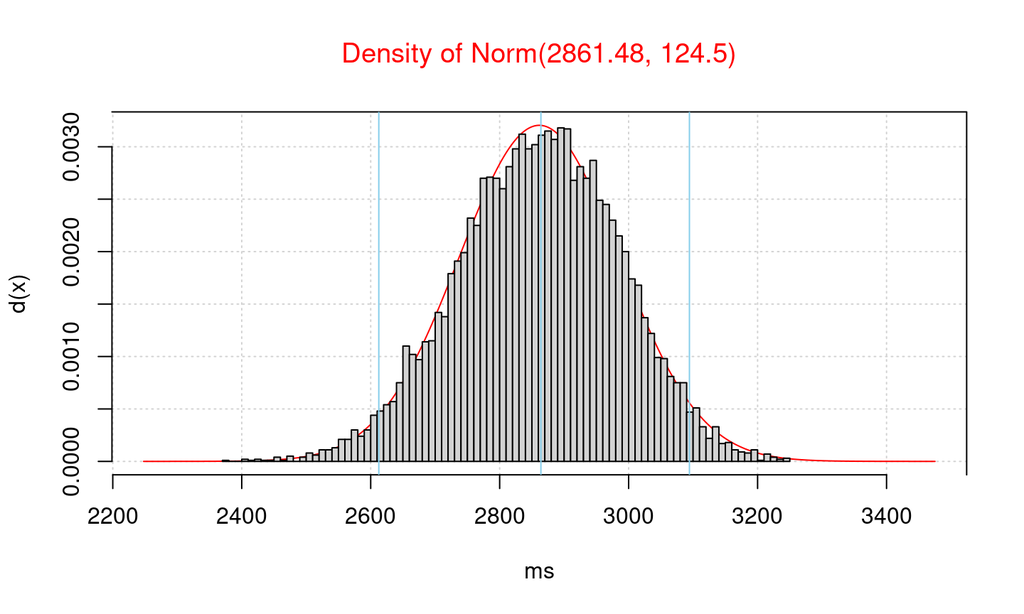

95% Confidence Interval: (2612.57ms, 3094.3ms)

## Summary

distances

means

errors

lower

higher

**\(\beta_0\)**

```
   40
```

169.22

4.09

161.47

177.53

**\(\beta_1\)**

```
   60
```

452.61

13.95

423.87

478.51

**\(\beta_2\)**

```
   80
```

874.95

18.3

839.7

911.92

**\(\beta_3\)**

```
  100
```

2861.48

124.5

2612.57

3094.3